# CE510: Modern Statistics for Engineers

## Winter 2026 Final Project

Completed by Brandon Auyeung for Dr. Peyman Abbaszadeh.

Let us define variables.

$ S \equiv \text{suspended sediment concentration, SSC} \ \dot{=} \ [\frac{M}{L^3}]$

$ Q \equiv \text{discharge} \ \dot{=} \ [L^3]$

$\alpha, \ \beta \equiv \text{model parameters} $

$\sigma \equiv \text{unknown measurement error}$

Note:

S in Excel file is given in mg/L. Q in Excel is given in cfs.

1 $\text{mg/L}$ = 0.001 $\text{kg/m}^3$. 1 $\text{cfs}$ = 0.0283168 $\text{m}^3\text{/s}$

```python
import numpy as np
import pandas as pd
from icecream import ic
import matplotlib.pyplot as plt
import seaborn as sns
import scipy.stats as stats
import scipy.optimize as opt
import emcee
```

```python
data = pd.read_excel("Data_Final_Project.xlsx", skiprows=0)
data = data.drop(["Agency","Station ID"], axis=1)
data
```

|  | Date | Suspended sediment concentration | Discharge |
| --- | --- | --- | --- |
| 0 | 1961-10-01 | 4.0 | 327 |
| 1 | 1961-10-02 | 4.0 | 315 |
| 2 | 1961-10-03 | 4.0 | 309 |
| 3 | 1961-10-04 | 4.0 | 303 |
| 4 | 1961-10-05 | 4.0 | 294 |
| ... | ... | ... | ... |
| 3646 | 1971-09-25 | 1.0 | 444 |
| 3647 | 1971-09-26 | 2.0 | 485 |
| 3648 | 1971-09-27 | 4.0 | 554 |
| 3649 | 1971-09-28 | 4.0 | 623 |
| 3650 | 1971-09-29 | 7.0 | 740 |

3651 rows × 3 columns

```python
x = data["Discharge"] * 0.0283168
y = data["Suspended sediment concentration"] * 0.001
data.describe()
```

|  | Date | Suspended sediment concentration | Discharge |
| --- | --- | --- | --- |
| count | 3651 | 3587.000000 | 3651.000000 |
| mean | 1966-09-30 00:00:00 | 14.227209 | 4081.558203 |
| min | 1961-10-01 00:00:00 | 0.000000 | 186.000000 |
| 25% | 1964-03-31 12:00:00 | 4.000000 | 655.000000 |
| 50% | 1966-09-30 00:00:00 | 6.000000 | 2020.000000 |
| 75% | 1969-03-30 12:00:00 | 16.000000 | 5270.000000 |
| max | 1971-09-29 00:00:00 | 452.000000 | 46500.000000 |
| std | NaN | 23.279191 | 5267.264166 |

## a) Use the flat prior assumption for $\beta$ and visualize the ensemble of curves.

$$ S(Q_i | \alpha, \ \beta) = \alpha Q_i^{\beta}$$

Assuming Gaussian error in $S_{obs}$:

$$ \mathbb{P}(Q_iS_i | \alpha, \beta, \sigma) = \frac{1}{\sqrt{2\pi\sigma^2}}\text{exp}\left[ \frac{-[S_i - S(Q_i | \alpha, \beta)]^2}{2\sigma^2} \right]$$

$$ \mathcal{L} = \mathbb{P}(\vec{Q_i}\vec{S_i} | \alpha, \beta, \sigma) \propto (2\pi\sigma^2)^{-N/2}\text{exp}\left[ -\frac{1}{2\sigma^2} \sum_{i-1}^{N}[S_i - S(Q_i | \alpha, \beta)]^2\right]$$

```python
def log_likelihood(theta, x, y):
    alpha, beta, log_sigma = theta
    sigma = np.exp(log_sigma)
    model = alpha * x ** beta
    return -0.5 * len(x) * np.log(2 * np.pi * sigma ** 2) - 0.5*sigma ** (-2) * np.sum((y - model) ** 2)

# if i dont add anything, flat prior is assumed (log(flat prior))

from scipy.optimize import minimize

np.random.seed(0)
nll = lambda *args: -log_likelihood(*args)
initial = np.array([0.5, 1, 20]) + 0.1 * np.random.randn(3)
soln = minimize(nll, initial, args=(x, y))
alpha_nll, beta_nll, sigma_nll = soln.x

print('Via MLE')
print(f"alpha = {alpha_nll}")
print(f"beta = {beta_nll:.3f}")
print(f"sigma = {np.exp(sigma_nll):.3f}")
```

```
Via MLE
alpha = 0.00036921819104270454
beta = 0.794
sigma = 0.018
```

```
(0.0, 0.25)
```

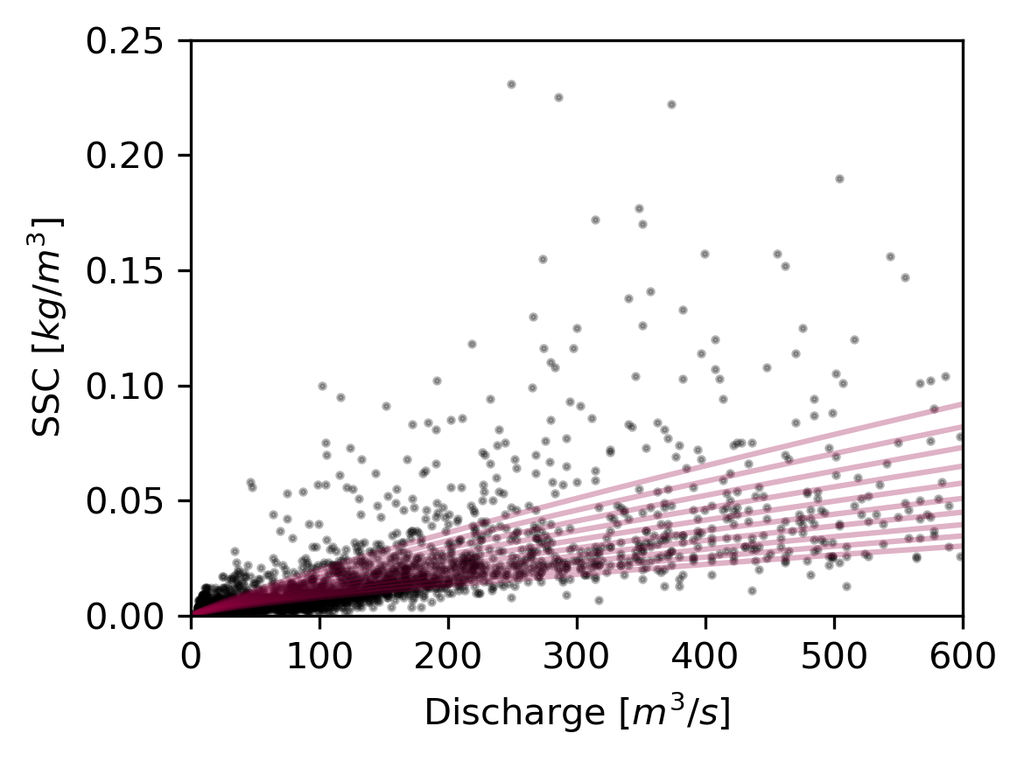

```python
# using the alpha and beta from MLE, generate ensemble of curves and visualize
alpha_guesses = np.linspace(0.00025, 0.0004, 10)
beta_guesses = np.linspace(0.75, 0.85, 10)

fig, ax = plt.subplots(figsize=(4,3), tight_layout=True, dpi=300)

Q_line = np.linspace(0, 1000, 10000)

ax.plot(x,y, color = "black", alpha = 0.3, linestyle = "None", marker = ".", markersize = 3)

for alpha, beta in zip(alpha_guesses, beta_guesses):
    ax.plot(Q_line, alpha * Q_line ** beta, color= '#980043', alpha=0.3)

ax.set_xlabel('Discharge $[m^3/s]$')
ax.set_ylabel('SSC $[kg/m^3]$')
ax.set_xlim(0, 600)
ax.set_ylim(0, 0.25)
```

## 2) Use the MCMC approach to fit a curve of best-fit along with the $\pm 2 \sigma$ uncertainty region.

$$\mathbb{P}(\alpha, \beta) \propto (1+\beta^2)^{-3/2}$$

```python
def log_prior(theta):
    alpha, beta, log_sigma = theta
    sigma = np.exp(log_sigma)
    # if not (0.01 < alpha < 0.03 and -20 < beta < 20 and 0 < sigma < 40):
    #     return -np.inf
    return -1.5 * np.log(1 + beta ** 2) + (1/np.log(sigma))

def log_posterior(theta, x, y):
    return log_prior(theta) + log_likelihood(theta, x, y)
```

```python
np.random.seed(0)

nwalkers = 50
ndim = 3
nburn = 1000
nsteps = 2000

sampler = emcee.EnsembleSampler(
    nwalkers, ndim, log_posterior, args=(x, y)
)
## sensitive to initial values
guesses = [alpha_nll, beta_nll, sigma_nll] + 0.001 * np.random.randn(nwalkers, ndim)

sampler.run_mcmc(guesses, nsteps, progress=False)
```

```
alpha = 0.00037732836247506745
beta = 0.791
sigma = 0.018
```

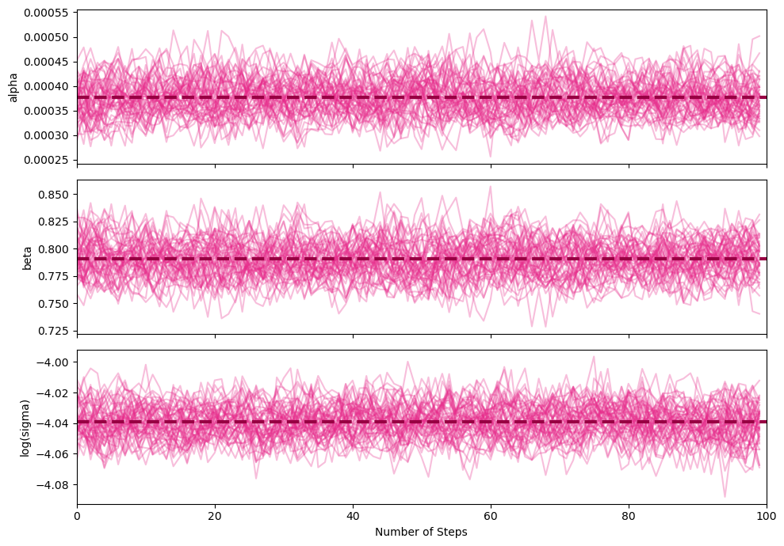

```python
fig, axes = plt.subplots(3, figsize=(10, 7), sharex=True, tight_layout=True)
samples = sampler.get_chain(discard=nburn, thin=10, flat=False)
# print(samples.shape)
labels = ["alpha", "beta", "log(sigma)"]
for i in range(ndim):
    ax = axes[i]
    for j in range(nwalkers):
        ax.plot(samples[:, j, i], "#e7298a", alpha=0.3)
    ax.set_xlim(0, len(samples[:, :, i]))
    ax.set_ylabel(labels[i])
    ax.hlines(np.mean(samples[:, :, i]), 0, len(samples[:, :, i]), color="#980043", linestyles='--', lw = 3)

axes[-1].set_xlabel("Number of Steps");

est_alpha = np.mean(samples[:, :, 0])
est_beta = np.mean(samples[:, :, 1])
est_sigma = np.mean(np.exp(samples[:, :, 2]))

print(f"alpha = {est_alpha}")
print(f"beta = {est_beta:.3f}")
print(f"sigma = {est_sigma:.3f}")
```

```python
# Create some convenience routines for plotting

def compute_sigma_level(trace1, trace2, nbins=20):
    """From a set of traces, bin by number of standard deviations"""
    L, xbins, ybins = np.histogram2d(trace1, trace2, nbins)

    L[L == 0] = 1E-16
    logL = np.log(L)

    shape = L.shape
    L = L.ravel()

    # obtain the indices to sort and unsort the flattened array
    i_sort = np.argsort(L)[::-1]
    i_unsort = np.argsort(i_sort)

    L_cumsum = L[i_sort].cumsum()
    L_cumsum /= L_cumsum[-1]

    xbins = 0.5 * (xbins[1:] + xbins[:-1])
    ybins = 0.5 * (ybins[1:] + ybins[:-1])

    return xbins, ybins, L_cumsum[i_unsort].reshape(shape)

def plot_MCMC_trace(ax, xdata, ydata, trace, scatter=False, **kwargs):
    """Plot traces and contours"""
    xbins, ybins, sigma = compute_sigma_level(trace[0], trace[1])
    ax.contour(xbins, ybins, sigma.T, levels=[0.683, 0.955], **kwargs)
    if scatter:
        ax.plot(trace[0], trace[1], ',k', alpha=0.1)
    # ax.set_xlim(-1, 1)
    # ax.set_ylim(0, 1)
    ax.set_xlabel(r'$\alpha$')
    ax.set_ylabel(r'$\beta$')


def plot_MCMC_model(ax, xdata, ydata, trace):
    """Plot the linear model and 2sigma contours"""
    ax.plot(xdata, ydata, 'ok')

    alpha, beta = trace[:2]
    xfit = np.linspace(-20, 120, 10)
    yfit = alpha[:, None] + beta[:, None] * xfit
    mu = yfit.mean(0)
    sig = 2 * yfit.std(0)

    ax.plot(xfit, mu, '-k')
    ax.fill_between(xfit, mu - sig, mu + sig, color='lightgray')

    ax.set_xlabel('Q $[m^3/s]$')
    ax.set_ylabel('SSC $[kg/m^3]$')

def plot_MCMC_results(xdata, ydata, trace, colors='k'):
    """Plot both the trace and the model together"""
    fig, ax = plt.subplots(1, 2, figsize=(10, 4))
    plot_MCMC_trace(ax[0], xdata, ydata, trace, True, colors=colors)
    plot_MCMC_model(ax[1], xdata, ydata, trace)
```

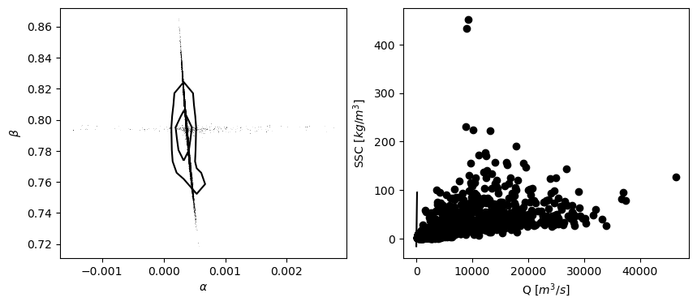

```python
emcee_trace = sampler.chain[:, :, :].reshape(-1, ndim).T
plot_MCMC_results(data['Discharge'], data['Suspended sediment concentration'], emcee_trace)
# Show the figure
# plt.tight_layout()
```

```
(0.0, 0.25)
```

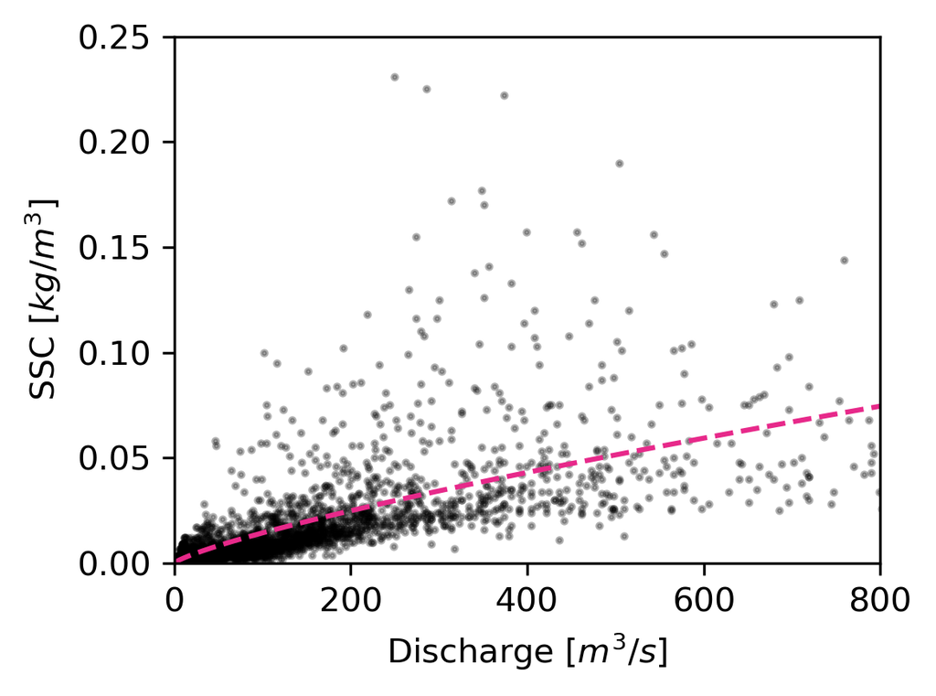

```python
fig, ax = plt.subplots(figsize=(4,3), tight_layout=True, dpi=300)
Q_line = np.linspace(0, 1000, 10000) # test muliple flow rate values

ax.plot(x,y, color = "black", alpha = 0.3, linestyle = "None", marker = ".", markersize = 3)
ax.plot(Q_line, est_alpha*Q_line**est_beta, linestyle='--', alpha = 1, color = "#e7298a")

ax.set_xlabel('Discharge $[m^3/s]$')
ax.set_ylabel('SSC $[kg/m^3]$')
ax.set_xlim(0, 800)
ax.set_ylim(0, 0.25)
```

## 3. Use KDE to visualize the resulting traces marginalized over the uncertain parameter $\sigma$.

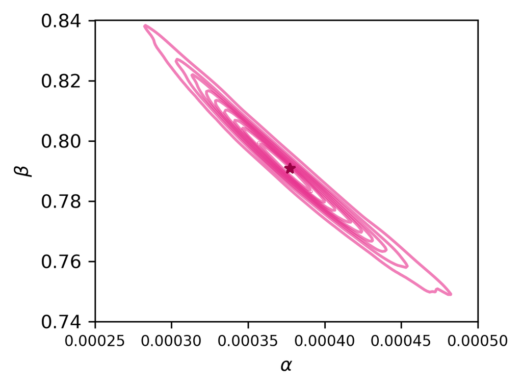

```python
fig, ax = plt.subplots(figsize=(4,3), tight_layout=True, dpi=300)
sns.kdeplot(x= np.ravel(samples[:, :, 0]), y = np.ravel(samples[:, :, 1]), color = "#e7298a", alpha = 0.6)
plt.xlim(0.00025, 0.0005)
plt.xticks(fontsize = 8)
plt.xlabel('$\\alpha$')
plt.ylim(0.74, 0.84)
plt.ylabel('$\\beta$')
plt.plot(est_alpha, est_beta, '*', color = "#980043")
```

## 4. Use Least Squares method to find the model parameters $\alpha$ and $\beta$. Visualize the result similar to Figure 2.4 in lecture 2.

```python
def cost_function(alpha, beta):
 predictions = alpha * x ** beta
 residuals = y - predictions
 return np.sum(residuals**2)

initial_guess = [alpha_nll, beta_nll] # Initial guess for a, b, and c
result = minimize(lambda params: cost_function(params[0], params[1]), initial_guess)
alpha_ls, beta_ls = result.x
```

```python
print('Via Least Squares')
print(f"    alpha = {alpha_ls}")
print(f"    beta = {beta_ls:.3f}")

print('Via Maximum Likelihood Estimation')
print(f"    alpha = {alpha_nll}")
print(f"    beta = {beta_nll:.3f}")

print('Via MCMC')
print(f"    alpha = {np.mean(samples[:, :, 0])}")
print(f"    beta = {np.mean(samples[:, :, 1]):.3f}")
```

```
Via Least Squares
    alpha = 0.00036921845947102106
    beta = 0.794
Via Maximum Likelihood Estimation
    alpha = 0.00036921819104270454
    beta = 0.794
Via MCMC
    alpha = 0.00037732836247506745
    beta = 0.791
```

```
(0.0, 0.25)
```

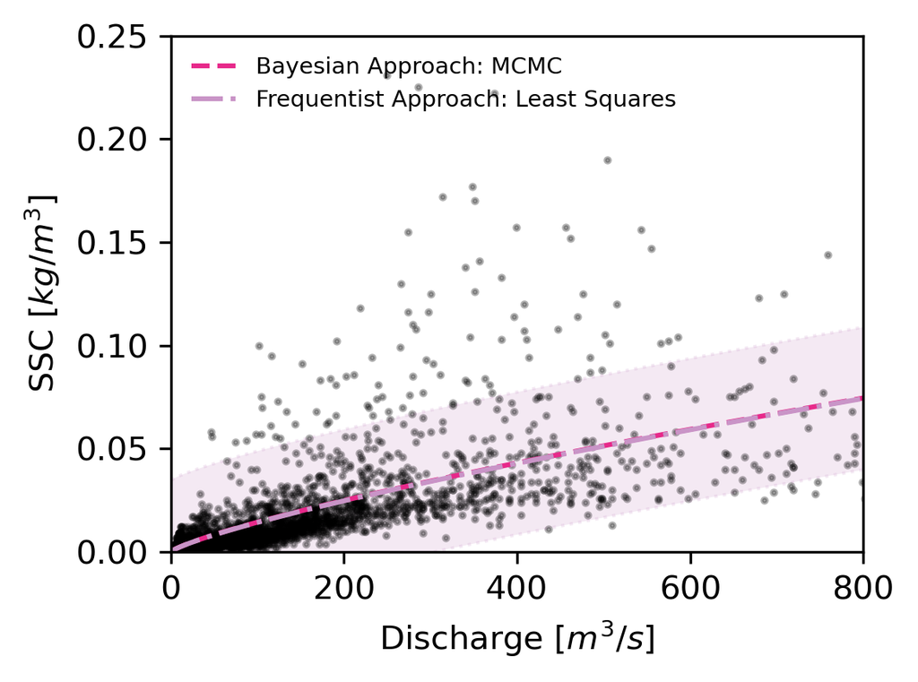

```python
fig, ax = plt.subplots(figsize=(4,3), tight_layout=True, dpi=300)
Q_line = np.linspace(0, 1000, 10000) # test muliple flow rate values

ax.plot(x,y, color = "black", alpha = 0.3, linestyle = "None", marker = ".", markersize = 3)
ax.plot(Q_line, est_alpha*Q_line**est_beta, '--', alpha = 1, color = "#e7298a", label = "Bayesian Approach: MCMC")

ax.plot(Q_line, alpha_ls*Q_line**beta_ls, linestyle='-.', alpha = 1, color ='#c994c7', label = "Frequentist Approach: Least Squares")
ax.fill_between(Q_line, alpha_ls*Q_line**beta_ls - 1.96 * est_sigma, alpha_ls*Q_line**beta_ls + 1.96 * est_sigma,\
                linestyle=':', color='#c994c7', alpha=0.2)

plt.legend(frameon = False, loc = 'upper left', fontsize = 7)

ax.set_xlabel('Discharge $[m^3/s]$')
ax.set_ylabel('SSC $[kg/m^3]$')
ax.set_xlim(0, 800)
ax.set_ylim(0, 0.25)
```